# Vectorized Int-to-Int Value Lookup R

### `fmatch` in “fastmatch”

Unlike built-in `match` with it’s sequential lookup, `fastmatch::fmatch` builds the lookup hashtable at the first iteration, and later uses it. It is developed as a drop-in replacement for `match` and can result in dramatically better times for long tables.

```r
doFMatch <- function(sKeys, keys, values) {
   ## find values, corresponding to keys
   for(key in sKeys) {
      v <- values[fastmatch::fmatch(key, keys)]
   }
}

time <- foreach(n = ns, .combine=c) %do% {
   values <- sample(1000000000L, ns)
   keys <- sample(values)
                           # keys are values in random order
   shuffledKeys <- foreach(l = seq(length=L)) %do% {
      sample(keys, B, replace=TRUE)
   }
                           # a list of L index vectors of size B
   microbenchmark::microbenchmark(doFMatch(shuffledKeys, keys, values), times=2L,
                                  control=list(warmup=1)) %>%
                           # find keys in random order
      as.data.frame() %>%
      extract2("time") %>%  # extract time in nanoseconds
      mean() %>%
      divide_by(1e6) %>%
      set_names(n)
}
results[["fmatch"]] <- time
time
```

```
##       30      100      300     1000     3000    10000    30000    1e+05
## 3.467176 1.077946 1.051287 1.254798 1.148966 1.320558 1.038458 1.059002
##    3e+05    1e+06
## 0.981577 1.008037
```

### Hashed environment

For single-value lookup, hashed environments–the closest R offers for hashmaps–[provide the best performance](https://otoomet.github.io/simple_lookup_R.html). Unfortunately these do not support vectorized access, so we have to loop through the vector of keys. Note also that this requires the keys to be represented as character vector. This works well for integers. We create a vector of values, assign the keys to it as names, convert the named vector to a list, and finally into a hashed environment with `list2env(., hash=TRUE)`. We perform the lookup in the environment with `values[[key]]` where keys are converted to characters earlier in vectorized fashion.

```r
doHEnv <- function(sKeys, values) {
   ## find values, corresponding to keys
   for(bKeys in sKeys) {
                           # extract the vector of bunch keys
      for(key in as.character(bKeys)) {
         v <- values[[key]]
      }
   }
}
time <- foreach(n = ns, .combine=c) %do% {
   values <- sample(1000000000L, n)
   keys <- sample(values)
                           # we need character values to access the environment
   values <- setNames(values, keys) %>%
                           # make it into a vector...
      as.list() %>%
      list2env(hash=TRUE)
                           # and convert into a hashed environment
   shuffledKeys <- foreach(l = seq(length=L)) %do% {
      sample(keys, B, replace=TRUE)
   }
                           # a list of L index vectors of size B
   microbenchmark::microbenchmark(doHEnv(shuffledKeys, values), times=2L,
                                  control=list(warmup=1)) %>%
                           # find keys in random order
      as.data.frame() %>%
      extract2("time") %>%  # extract time in nanoseconds
      mean() %>%
      divide_by(1e6) %>%
      set_names(n)
}
results[["hashed env"]] <- time
time
```

```
##         30        100        300       1000       3000      10000
##   38.41025   37.87887   39.26490   41.22010   45.20896   53.55510
##      30000      1e+05      3e+05      1e+06
##   79.44599  164.35403  387.01702 1214.16288
```

Unlike single results, hashed environments appear slow. At the largest table, the time 1.214s is about 1000x slower than `fmatch`, and even slower than named vectors–the definitive looser when testing the single-key lookups.

### Data.tables

data.table library offers an alternative to data frame and contains built-in ordering by index. We use the vectorized index (as key) lookup of a the value from data.table

```r
doDT <- function(sKeys, dtable) {
   ## find values, corresponding to keys
   for(key in sKeys) {
      v <- dtable[key, values]
   }
}
time <- foreach(n = ns, .combine=c) %do% {
   values <- sample(1000000000L, n)
   keys <- sample(values)
                           # we need character values to access the environment
   dtable <- data.table(keys, values, key="keys")
                           # set hashed index to the table
   shuffledKeys <- foreach(l = seq(length=L)) %do% {
      sample(keys, B, replace=TRUE)
   }
                           # a list of L index vectors of size B
   microbenchmark::microbenchmark(doDT(shuffledKeys, dtable), times=3L,
                                  control=list(warmup=2)) %>%
      as.data.frame() %>%
      extract2("time") %>%  # extract time in nanoseconds
      mean() %>%
      divide_by(1e6) %>%
      set_names(n)
}
results[["data.table"]] <- time
time
```

```
##        30       100       300      1000      3000     10000     30000
## 18.241417  8.101245  8.143146  8.210385  8.120365  8.097955  8.170750
##     1e+05     3e+05     1e+06
##  8.088662  8.162855  8.087391
```

Unlike in case of single-key lookup, data tables appear quite fast. Their access time appears to be remarkably constant over different sizes. Clearly, these offer a good alternative for `fmatch`, at least in case of multi-value lookups. The huge performance gain for vectorized lookup compared to the single-index case suggests that `[.data.table` has quite substantial overhead.

### Another benchmark: do the same in python

```python
import time
import random
import pandas as pd
L = 10
B = 10000
ns = [30, 100, 300, 1000, 3000, 10000, 30000, 100000, 300000, 1000000]
td = []
for n in ns:
    values = [i for i in range(n)]
    keys = values.copy()
    random.shuffle(keys)
    table = dict(zip(values, keys))
    lk = [[random.choice(keys) for _ in range(B)]
           for _ in range(L)]
    # list of list of keys to be looked up
    t0 = time.time()
    # start the clock
    for bKeys in lk:
        # take the bunch
        for k in bKeys:
            # take individual keys in bunches
            v = table[k]
    td.append((time.time() - t0)*1000)
    # in milliseconds
## Now repeat with pandas
tp = []
for n in ns:
    values = [i for i in range(n)]
    keys = values.copy()
    random.shuffle(keys)
    #
    table = pd.DataFrame({ "values" : values}, index=keys)
    lk = [[random.choice(keys) for _ in range(B)]
           for _ in range(L)]
    # list of list of keys to be looked up
    t0 = time.time()
    # start the clock
    for bKeys in lk:
        # take the bunch
        v = table.loc[bKeys]
        # index by vector of keys
    tp.append((time.time() - t0)*1000)
df = pd.DataFrame({ "n" : ns, "dict" : td , "pandas" : tp})
df.to_csv("python_results.csv", index=False)
print(df)
```

```
##         dict        n      pandas
## 0   9.900331       30   56.673765
## 1   9.639502      100   54.870844
## 2   9.468794      300   55.068493
## 3   9.374380     1000   61.885595
## 4   9.456873     3000   69.737673
## 5  10.689974    10000  112.521410
## 6  11.074543    30000  144.275427
## 7  15.145540   100000  205.878973
## 8  25.300026   300000  384.438038
## 9  31.639814  1000000  964.721203
```

Python dict appears to be outperformed by several R methods here. Looping to address the non-vectorized lookup only is probably the main culprit. It also appears that plain indexed lookup in pandas does even worse.

# Conclusions and the final plot

Finally, here is a plot with all approaches together.

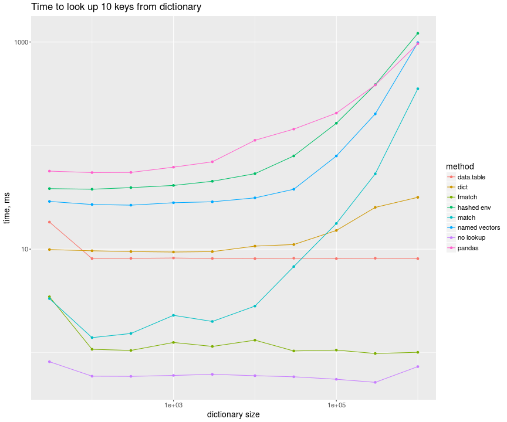

As a surprise, the basic python methods do not perform well. Dicts that offer by far superior performance for single-element lookup are slow now–probably because the element lookup is not vectorized at C level. And pandas, also offering index-based hashtable, are even slower. It suggests that under the hood the index lookup is not vectorized either. As the aim of this post is to compare various R methods and benchmark these with the simple python ways, I do not asses the question about existence of superior methods in python.